# PML_weight_lifting_exercise_prediction

ADROIT KIM

September 26, 2015

## Authors of the original work and Source of the Data.

The training data for this project are available here: https://d396qusza40orc.cloudfront.net/predmachlearn/pml-training.csv

The test data are available here: https://d396qusza40orc.cloudfront.net/predmachlearn/pml-testing.csv

The data for this project come from this source: http://groupware.les.inf.puc-rio.br/har.

The authors and original paper are: **Velloso, E.; Bulling, A.; Gellersen, H.; Ugulino, W.; Fuks, H. Qualitative Activity Recognition of Weight Lifting Exercises. Proceedings of 4th International Conference in Cooperation with SIGCHI (Augmented Human ’13) . Stuttgart, Germany: ACM SIGCHI, 2013.**

Read more: http://groupware.les.inf.puc-rio.br/har#ixzz3mnPgZVzi

### 1.explore the data.

Let’s read training and testing data.

```r
trainingOrig <- read.csv("./pml-training.csv", row.names = 1, na.strings = c("",NA))
testingOrig <- read.csv("./pml-testing.csv", row.names = 1, na.strings = c("",NA))
```

Let’s check the dimensions of both training and testing set.

```r
dim(trainingOrig)
```

```
## [1] 19622   159
```

```r
dim(testingOrig)
```

```
## [1]  20 159
```

same number of columns. I was expecting testing set to have 1 less column, namely, “classe” variable, the one we are trying to predict. Let’s check whether column names are same for both datasets.

```r
names(trainingOrig) %in% names(testingOrig)
```

```
##   [1]  TRUE  TRUE  TRUE  TRUE  TRUE  TRUE  TRUE  TRUE  TRUE  TRUE  TRUE
##  [12]  TRUE  TRUE  TRUE  TRUE  TRUE  TRUE  TRUE  TRUE  TRUE  TRUE  TRUE
##  [23]  TRUE  TRUE  TRUE  TRUE  TRUE  TRUE  TRUE  TRUE  TRUE  TRUE  TRUE
##  [34]  TRUE  TRUE  TRUE  TRUE  TRUE  TRUE  TRUE  TRUE  TRUE  TRUE  TRUE
##  [45]  TRUE  TRUE  TRUE  TRUE  TRUE  TRUE  TRUE  TRUE  TRUE  TRUE  TRUE
##  [56]  TRUE  TRUE  TRUE  TRUE  TRUE  TRUE  TRUE  TRUE  TRUE  TRUE  TRUE
##  [67]  TRUE  TRUE  TRUE  TRUE  TRUE  TRUE  TRUE  TRUE  TRUE  TRUE  TRUE
##  [78]  TRUE  TRUE  TRUE  TRUE  TRUE  TRUE  TRUE  TRUE  TRUE  TRUE  TRUE
##  [89]  TRUE  TRUE  TRUE  TRUE  TRUE  TRUE  TRUE  TRUE  TRUE  TRUE  TRUE
## [100]  TRUE  TRUE  TRUE  TRUE  TRUE  TRUE  TRUE  TRUE  TRUE  TRUE  TRUE
## [111]  TRUE  TRUE  TRUE  TRUE  TRUE  TRUE  TRUE  TRUE  TRUE  TRUE  TRUE
## [122]  TRUE  TRUE  TRUE  TRUE  TRUE  TRUE  TRUE  TRUE  TRUE  TRUE  TRUE
## [133]  TRUE  TRUE  TRUE  TRUE  TRUE  TRUE  TRUE  TRUE  TRUE  TRUE  TRUE
## [144]  TRUE  TRUE  TRUE  TRUE  TRUE  TRUE  TRUE  TRUE  TRUE  TRUE  TRUE
## [155]  TRUE  TRUE  TRUE  TRUE FALSE
```

```r
names(testingOrig) %in% names(trainingOrig)
```

```
##   [1]  TRUE  TRUE  TRUE  TRUE  TRUE  TRUE  TRUE  TRUE  TRUE  TRUE  TRUE
##  [12]  TRUE  TRUE  TRUE  TRUE  TRUE  TRUE  TRUE  TRUE  TRUE  TRUE  TRUE
##  [23]  TRUE  TRUE  TRUE  TRUE  TRUE  TRUE  TRUE  TRUE  TRUE  TRUE  TRUE
##  [34]  TRUE  TRUE  TRUE  TRUE  TRUE  TRUE  TRUE  TRUE  TRUE  TRUE  TRUE
##  [45]  TRUE  TRUE  TRUE  TRUE  TRUE  TRUE  TRUE  TRUE  TRUE  TRUE  TRUE
##  [56]  TRUE  TRUE  TRUE  TRUE  TRUE  TRUE  TRUE  TRUE  TRUE  TRUE  TRUE
##  [67]  TRUE  TRUE  TRUE  TRUE  TRUE  TRUE  TRUE  TRUE  TRUE  TRUE  TRUE
##  [78]  TRUE  TRUE  TRUE  TRUE  TRUE  TRUE  TRUE  TRUE  TRUE  TRUE  TRUE
##  [89]  TRUE  TRUE  TRUE  TRUE  TRUE  TRUE  TRUE  TRUE  TRUE  TRUE  TRUE
## [100]  TRUE  TRUE  TRUE  TRUE  TRUE  TRUE  TRUE  TRUE  TRUE  TRUE  TRUE
## [111]  TRUE  TRUE  TRUE  TRUE  TRUE  TRUE  TRUE  TRUE  TRUE  TRUE  TRUE
## [122]  TRUE  TRUE  TRUE  TRUE  TRUE  TRUE  TRUE  TRUE  TRUE  TRUE  TRUE
## [133]  TRUE  TRUE  TRUE  TRUE  TRUE  TRUE  TRUE  TRUE  TRUE  TRUE  TRUE
## [144]  TRUE  TRUE  TRUE  TRUE  TRUE  TRUE  TRUE  TRUE  TRUE  TRUE  TRUE
## [155]  TRUE  TRUE  TRUE  TRUE FALSE
```

```r
names(trainingOrig[159])
```

```
## [1] "classe"
```

```r
names(testingOrig[159])
```

```
## [1] "problem_id"
```

It shows that the last column of both datasets are different. training set has “classe” variable that test set do not have, unsurprisingly. testing set has “problem_id” variable that training set do not have. “problem_id” variable is for submitting answers to course website. We can ignore it for now.

We now examine the training dataset.

```r
summary(trainingOrig)
```

```
##     user_name    raw_timestamp_part_1 raw_timestamp_part_2
##  adelmo  :3892   Min.   :1.322e+09    Min.   :   294
##  carlitos:3112   1st Qu.:1.323e+09    1st Qu.:252912
##  charles :3536   Median :1.323e+09    Median :496380
##  eurico  :3070   Mean   :1.323e+09    Mean   :500656
##  jeremy  :3402   3rd Qu.:1.323e+09    3rd Qu.:751891
##  pedro   :2610   Max.   :1.323e+09    Max.   :998801
##
##           cvtd_timestamp  new_window    num_window      roll_belt
##  28/11/2011 14:14: 1498   no :19216   Min.   :  1.0   Min.   :-28.90
##  05/12/2011 11:24: 1497   yes:  406   1st Qu.:222.0   1st Qu.:  1.10
##  30/11/2011 17:11: 1440               Median :424.0   Median :113.00
##  05/12/2011 11:25: 1425               Mean   :430.6   Mean   : 64.41
##  02/12/2011 14:57: 1380               3rd Qu.:644.0   3rd Qu.:123.00
##  02/12/2011 13:34: 1375               Max.   :864.0   Max.   :162.00
##  (Other)         :11007
##    pitch_belt          yaw_belt       total_accel_belt kurtosis_roll_belt
##  Min.   :-55.8000   Min.   :-180.00   Min.   : 0.00    #DIV/0!  :   10
##  1st Qu.:  1.7600   1st Qu.: -88.30   1st Qu.: 3.00    -1.908453:    2
##  Median :  5.2800   Median : -13.00   Median :17.00    -0.016850:    1
##  Mean   :  0.3053   Mean   : -11.21   Mean   :11.31    -0.021024:    1
##  3rd Qu.: 14.9000   3rd Qu.:  12.90   3rd Qu.:18.00    -0.025513:    1
##  Max.   : 60.3000   Max.   : 179.00   Max.   :29.00    (Other)  :  391
##                                                        NA's     :19216
##  kurtosis_picth_belt kurtosis_yaw_belt skewness_roll_belt
##  #DIV/0!  :   32     #DIV/0!:  406     #DIV/0!  :    9
##  47.000000:    4     NA's   :19216     0.000000 :    4
##  -0.150950:    3                       0.422463 :    2
##  -0.684748:    3                       -0.003095:    1
##  -1.750749:    3                       -0.010002:    1
##  (Other)  :  361                       (Other)  :  389
##  NA's     :19216                       NA's     :19216
##  skewness_roll_belt.1 skewness_yaw_belt max_roll_belt     max_picth_belt
##  #DIV/0!  :   32      #DIV/0!:  406     Min.   :-94.300   Min.   : 3.00
##  0.000000 :    4      NA's   :19216     1st Qu.:-88.000   1st Qu.: 5.00
##  -2.156553:    3                        Median : -5.100   Median :18.00
##  -3.072669:    3                        Mean   : -6.667   Mean   :12.92
##  -6.324555:    3                        3rd Qu.: 18.500   3rd Qu.:19.00
##  (Other)  :  361                        Max.   :180.000   Max.   :30.00
##  NA's     :19216                        NA's   :19216     NA's   :19216
```

[output cut: 313 more lines]

```
##  Min.   :-446.00   Min.   :-1280.0   Min.   :-896.0   Min.   :-973.0
##  1st Qu.:-182.00   1st Qu.: -616.0   1st Qu.:   2.0   1st Qu.: 191.0
##  Median : -39.00   Median : -378.0   Median : 591.0   Median : 511.0
##  Mean   : -55.29   Mean   : -312.6   Mean   : 380.1   Mean   : 393.6
##  3rd Qu.:  26.00   3rd Qu.:  -73.0   3rd Qu.: 737.0   3rd Qu.: 653.0
##  Max.   : 291.00   Max.   :  672.0   Max.   :1480.0   Max.   :1090.0
##
##  classe
##  A:5580
##  B:3797
##  C:3422
##  D:3216
##  E:3607
##
##
```

summary shows there are many variables composed of mostly NA values. There variables are nearly useless in our model. Not only becuase they are mostly NA filled but also many of them are irrelevant variables to begin with.

### 2.clean and split the data.

Let’s examine training set with regard to NA values.

```r
sum(is.na(trainingOrig)) # there are 1921600 NA values total in training set.
```

```
## [1] 1921600
```

```r
na_count <-sapply(trainingOrig, function(y) sum(is.na(y)))
min(na_count[na_count > 1])
```

```
## [1] 19216
```

```r
max(na_count[na_count > 1])
```

```
## [1] 19216
```

It shows there are 1921600 NA values total in training set, and interestingly, variable have either no NA values or exactly 19216 NA values.

Let’s check the number of NA values in each column, and discard any column with most of its values are NA.

```r
excludeVar <- names(trainingOrig) %in% names(na_count[na_count >10000]) # column names with more than 10000 NA values
trainingNoNA <- trainingOrig[!excludeVar]
rm(excludeVar, na_count)
```

We have reduced the number of variables from 159 to 59 and the number of NA values from 1921600 to 0.

```r
dim(trainingNoNA)
```

```
## [1] 19622    59
```

```r
names(trainingNoNA)
```

```
##  [1] "user_name"            "raw_timestamp_part_1" "raw_timestamp_part_2"
##  [4] "cvtd_timestamp"       "new_window"           "num_window"
##  [7] "roll_belt"            "pitch_belt"           "yaw_belt"
## [10] "total_accel_belt"     "gyros_belt_x"         "gyros_belt_y"
## [13] "gyros_belt_z"         "accel_belt_x"         "accel_belt_y"
## [16] "accel_belt_z"         "magnet_belt_x"        "magnet_belt_y"
## [19] "magnet_belt_z"        "roll_arm"             "pitch_arm"
## [22] "yaw_arm"              "total_accel_arm"      "gyros_arm_x"
## [25] "gyros_arm_y"          "gyros_arm_z"          "accel_arm_x"
## [28] "accel_arm_y"          "accel_arm_z"          "magnet_arm_x"
## [31] "magnet_arm_y"         "magnet_arm_z"         "roll_dumbbell"
## [34] "pitch_dumbbell"       "yaw_dumbbell"         "total_accel_dumbbell"
## [37] "gyros_dumbbell_x"     "gyros_dumbbell_y"     "gyros_dumbbell_z"
## [40] "accel_dumbbell_x"     "accel_dumbbell_y"     "accel_dumbbell_z"
## [43] "magnet_dumbbell_x"    "magnet_dumbbell_y"    "magnet_dumbbell_z"
## [46] "roll_forearm"         "pitch_forearm"        "yaw_forearm"
## [49] "total_accel_forearm"  "gyros_forearm_x"      "gyros_forearm_y"
## [52] "gyros_forearm_z"      "accel_forearm_x"      "accel_forearm_y"
## [55] "accel_forearm_z"      "magnet_forearm_x"     "magnet_forearm_y"
## [58] "magnet_forearm_z"     "classe"
```

```r
sum(is.na(trainingNoNA))
```

```
## [1] 0
```

Some peers in discussion board argue that we should exclude more variables, such as, “user_name”, but I think each user may have distinct exercise pattern and since training set and testing set have same users, I will not exclude such variables.

```r
levels(trainingOrig$user_name)
```

```
## [1] "adelmo"   "carlitos" "charles"  "eurico"   "jeremy"   "pedro"
```

```r
levels(testingOrig$user_name)
```

```
## [1] "adelmo"   "carlitos" "charles"  "eurico"   "jeremy"   "pedro"
```

Now we split “trainingNoNA” into “training” and “testing” dataset. Based on “classe” variable, 70% of “trainingNoNA” will be in “training” dataset and 30% in “testing” dataset. This “testing” dataset will serve as the validation dataset

```r
library(caret)
set.seed(12345)
inTrain <- createDataPartition(y = trainingNoNA$classe, p = 0.7, list = F)
training <- trainingNoNA[inTrain,]
testing <- trainingNoNA[-inTrain,]
dim(training);dim(testing)
```

```
## [1] 13737    59
```

```
## [1] 5885   59
```

```r
rm(inTrain)
```

### 3.train the models.

To hopefully speed up model building, I will use doParallel package.

```r
library(doParallel)
registerDoParallel()
```

#### 3-1.Classification and Regression Trees with Cross Validation

The first technique we will try is Classification and Regression Trees with 10 folds cross validation.

```r
library(caret); library(e1071); library(rpart); library(rpart.plot)

# Define cross-validation experiment
numFolds = trainControl( method = "cv", number = 10) # cross validation with 10 folds
cpGrid = expand.grid( .cp = seq(0.01,0.5,0.01))

# Perform the cross validation
train(classe ~ ., data = training, method = "rpart", trControl = numFolds, tuneGrid = cpGrid)
```

```
## CART
##
## 13737 samples
##    58 predictor
##     5 classes: 'A', 'B', 'C', 'D', 'E'
##
## No pre-processing
## Resampling: Cross-Validated (10 fold)
## Summary of sample sizes: 12362, 12363, 12365, 12363, 12363, 12364, ...
## Resampling results across tuning parameters:
##
##   cp    Accuracy   Kappa      Accuracy SD   Kappa SD
##   0.01  0.9085787  0.8846650  0.0242476541  0.03055611
##   0.02  0.8540510  0.8160774  0.0261724630  0.03299651
##   0.03  0.6944366  0.6156427  0.0614761376  0.07823300
##   0.04  0.5301672  0.4096240  0.0527989128  0.06518628
##   0.05  0.3658765  0.1246247  0.0078747347  0.01173280
##   0.06  0.3658765  0.1246247  0.0078747347  0.01173280
##   0.07  0.3658765  0.1246247  0.0078747347  0.01173280
##   0.08  0.3658765  0.1246247  0.0078747347  0.01173280
##   0.09  0.3658765  0.1246247  0.0078747347  0.01173280
##   0.10  0.3658765  0.1246247  0.0078747347  0.01173280
##   0.11  0.3658765  0.1246247  0.0078747347  0.01173280
##   0.12  0.2843415  0.0000000  0.0002392295  0.00000000
##   0.13  0.2843415  0.0000000  0.0002392295  0.00000000
##   0.14  0.2843415  0.0000000  0.0002392295  0.00000000
##   0.15  0.2843415  0.0000000  0.0002392295  0.00000000
##   0.16  0.2843415  0.0000000  0.0002392295  0.00000000
##   0.17  0.2843415  0.0000000  0.0002392295  0.00000000
##   0.18  0.2843415  0.0000000  0.0002392295  0.00000000
##   0.19  0.2843415  0.0000000  0.0002392295  0.00000000
##   0.20  0.2843415  0.0000000  0.0002392295  0.00000000
##   0.21  0.2843415  0.0000000  0.0002392295  0.00000000
##   0.22  0.2843415  0.0000000  0.0002392295  0.00000000
##   0.23  0.2843415  0.0000000  0.0002392295  0.00000000
##   0.24  0.2843415  0.0000000  0.0002392295  0.00000000
##   0.25  0.2843415  0.0000000  0.0002392295  0.00000000
##   0.26  0.2843415  0.0000000  0.0002392295  0.00000000
##   0.27  0.2843415  0.0000000  0.0002392295  0.00000000
##   0.28  0.2843415  0.0000000  0.0002392295  0.00000000
```

[output cut: 10 more lines]

```
##   0.39  0.2843415  0.0000000  0.0002392295  0.00000000
##   0.40  0.2843415  0.0000000  0.0002392295  0.00000000
##   0.41  0.2843415  0.0000000  0.0002392295  0.00000000
##   0.42  0.2843415  0.0000000  0.0002392295  0.00000000
##   0.43  0.2843415  0.0000000  0.0002392295  0.00000000
##   0.44  0.2843415  0.0000000  0.0002392295  0.00000000
##   0.45  0.2843415  0.0000000  0.0002392295  0.00000000
##   0.46  0.2843415  0.0000000  0.0002392295  0.00000000
##   0.47  0.2843415  0.0000000  0.0002392295  0.00000000
##   0.48  0.2843415  0.0000000  0.0002392295  0.00000000
##   0.49  0.2843415  0.0000000  0.0002392295  0.00000000
##   0.50  0.2843415  0.0000000  0.0002392295  0.00000000
##
## Accuracy was used to select the optimal model using  the largest value.
## The final value used for the model was cp = 0.01.
```

```r
rm(numFolds, cpGrid)
```

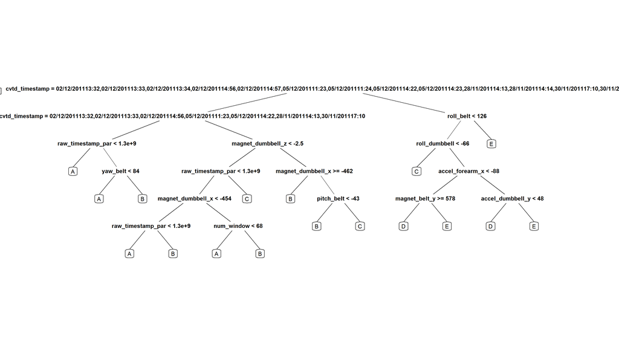

```r
# Create a new CART model
modelCART <- rpart(classe ~ ., data = training, method="class", cp = 0.01)
prp(modelCART)
```

```r
# Make predictions
predictCART = predict(modelCART, newdata = testing, type = "class")
confusionMatrix(data = predictCART, reference = testing$classe)
```

```
## Confusion Matrix and Statistics
##
##           Reference
## Prediction    A    B    C    D    E
##          A 1624   54    4    2    0
##          B   37  943   59   47    0
##          C   13  136  947  156   44
##          D    0    6   16  716  134
##          E    0    0    0   43  904
##
## Overall Statistics
##
##                Accuracy : 0.8724
##                  95% CI : (0.8636, 0.8808)
##     No Information Rate : 0.2845
##     P-Value [Acc > NIR] : < 2.2e-16
##
##                   Kappa : 0.8386
##  Mcnemar's Test P-Value : NA
##
## Statistics by Class:
##
##                      Class: A Class: B Class: C Class: D Class: E
## Sensitivity            0.9701   0.8279   0.9230   0.7427   0.8355
## Specificity            0.9858   0.9699   0.9282   0.9683   0.9910
## Pos Pred Value         0.9644   0.8683   0.7307   0.8211   0.9546
## Neg Pred Value         0.9881   0.9592   0.9828   0.9505   0.9640
## Prevalence             0.2845   0.1935   0.1743   0.1638   0.1839
## Detection Rate         0.2760   0.1602   0.1609   0.1217   0.1536
## Detection Prevalence   0.2862   0.1845   0.2202   0.1482   0.1609
## Balanced Accuracy      0.9779   0.8989   0.9256   0.8555   0.9133
```

Making prediction on our validation set, “testing”, came to be little less optimistic in terms of accuracy. Out of sample error to be $1 - 0.8724 \approx 0.13$. Let’s make prediction on the original test set.

```r
# Make prediction on "testingOrig", the original testing data set.
predictionCART <- predict(modelCART, newdata = testingOrig, type = "class")
predictionCART
```

```
##  1  2  3  4  5  6  7  8  9 10 11 12 13 14 15 16 17 18 19 20
##  B  A  C  A  A  E  D  C  A  A  B  C  B  A  E  E  A  B  B  B
## Levels: A B C D E
```

Using CART model, we predict the “classe” variable of the original testing dataset to be

> **B, A, C, A, A, E, D, C, A, A, B, C, B, A, E, E, A, B, B, B.**

#### 3-2.Random Forest

Let’s do similar prediction using Random Forest. Random Forest does not need cross-validation, so we won’t use 10 folds cv this time.

```r
library(randomForest)

# Build random forest model
modelRF = randomForest(classe ~ ., data = training)

# Make predictions
predictRF = predict(modelRF, newdata = testing)
confusionMatrix(data = predictRF,reference = testing$classe)
```

```
## Confusion Matrix and Statistics
##
##           Reference
## Prediction    A    B    C    D    E
##          A 1673    0    0    0    0
##          B    1 1139    3    0    0
##          C    0    0 1020    0    0
##          D    0    0    3  964    2
##          E    0    0    0    0 1080
##
## Overall Statistics
##
##                Accuracy : 0.9985
##                  95% CI : (0.9971, 0.9993)
##     No Information Rate : 0.2845
##     P-Value [Acc > NIR] : < 2.2e-16
##
##                   Kappa : 0.9981
##  Mcnemar's Test P-Value : NA
##
## Statistics by Class:
##
##                      Class: A Class: B Class: C Class: D Class: E
## Sensitivity            0.9994   1.0000   0.9942   1.0000   0.9982
## Specificity            1.0000   0.9992   1.0000   0.9990   1.0000
## Pos Pred Value         1.0000   0.9965   1.0000   0.9948   1.0000
## Neg Pred Value         0.9998   1.0000   0.9988   1.0000   0.9996
## Prevalence             0.2845   0.1935   0.1743   0.1638   0.1839
## Detection Rate         0.2843   0.1935   0.1733   0.1638   0.1835
## Detection Prevalence   0.2843   0.1942   0.1733   0.1647   0.1835
## Balanced Accuracy      0.9997   0.9996   0.9971   0.9995   0.9991
```

```r
rm(predictRF)
```

Unfortunately, random Forest gives the error if variables in training and testing dataset are different. I will first get rid of all columns in “testingOrig” which are not in “training” dataset, and assign it to “testingRF”. Then, rbind “training” and “testingRF” into “whole”“, then subset out”testingRF“. This way, I can sync variables of both datasets.

```r
# Make real prediction on "testingOrig"" data set.
includeVar <- names(testingOrig) %in% names(training) # columns of "testingOrig"", also in "training".
testingRF <- testingOrig[includeVar]
testingRF$classe <- NA # make "classe" column filled with NA values
whole <- rbind(training, testingRF)
testingRF <- subset(whole, is.na(classe))
rm(includeVar, whole)
predictionRF <- predict(modelRF, newdata = testingRF)
predictionRF
```

```
## 137381 137391 137401 137411  13742  13743  13744 137451  13746  13747
##      B      A      B      A      A      E      D      B      A      A
## 137481 137491 137501  13751 137521  13753 137541  13755 137561  13757
##      B      C      B      A      E      E      A      B      B      B
## Levels: A B C D E
```

Using Random Forest model, we predict the “classe” variable of the original testing dataset to be

> **B, A, B, A, A, E, D, B, A, A, B, C, B, A, E, E, A, B, B, B.**

Notice our prediction is slightly different from the one using CART model.

#### 3-3.Generalized Boosted Regression Modeling

Finally, let’s try out Generalized Boosted Regression Modeling with 10 fold cross validation and see if we get different result from previous methods.

```r
# Make sure to do doParellel(). Really slow!!!!!!
modelGBM <- train(classe ~ ., data = training, method = "gbm",
                  trControl = trainControl( method = "cv", number = 10), verbose = FALSE)
```

```r
# Make predictions
confusionMatrix(data = predict(modelGBM, newdata = testing),reference = testing$classe)
```

```
## Confusion Matrix and Statistics
##
##           Reference
## Prediction    A    B    C    D    E
##          A 1673    3    0    0    0
##          B    1 1134    1    0    0
##          C    0    1 1015    0    0
##          D    0    1   10  960    4
##          E    0    0    0    4 1078
##
## Overall Statistics
##
##                Accuracy : 0.9958
##                  95% CI : (0.9937, 0.9972)
##     No Information Rate : 0.2845
##     P-Value [Acc > NIR] : < 2.2e-16
##
##                   Kappa : 0.9946
##  Mcnemar's Test P-Value : NA
##
## Statistics by Class:
##
##                      Class: A Class: B Class: C Class: D Class: E
## Sensitivity            0.9994   0.9956   0.9893   0.9959   0.9963
## Specificity            0.9993   0.9996   0.9998   0.9970   0.9992
## Pos Pred Value         0.9982   0.9982   0.9990   0.9846   0.9963
## Neg Pred Value         0.9998   0.9989   0.9977   0.9992   0.9992
## Prevalence             0.2845   0.1935   0.1743   0.1638   0.1839
## Detection Rate         0.2843   0.1927   0.1725   0.1631   0.1832
## Detection Prevalence   0.2848   0.1930   0.1726   0.1657   0.1839
## Balanced Accuracy      0.9993   0.9976   0.9945   0.9964   0.9977
```

```r
# Make prediction on "testingOrig", the original testing data set.
predictionGBM <- predict(modelGBM, newdata = testingOrig)
predictionGBM
```

```
##  [1] B A B A A E D B A A B C B A E E A B B B
## Levels: A B C D E
```

```r
stopImplicitCluster()
```

Using Generalized Boosted Regression Modeling with 10-fold cross validation, we predict the “classe” variable of the original testing dataset to be

> **B, A, B, A, A, E, D, B, A, A, B, C, B, A, E, E, A, B, B, B.**

Notice our prediction is same with the one using Random Forest.

### 4.conclusion

Given that I’ve got two different answer sets worries me. But luckily I have two chances to check whether my answer is right or wrong. Since our predictions using Random Forest and Generalized Boosted Regression Modeling are same, it will be my first choice. It turns out both random forest and gbm models predicted correctly, while CART model did not. Not surprising since the expected out of sample error from CART model was nearly 0.13 while one from other models were less than 0.005.